# Transparencia del diseño de investigación

Guía para preregistrar un estudio

Investigador a cargo: Juan Carlos Castillo Asistente de investigación: Julio Iturra Pasante: Martín Venegas

30 September 2021

Uno de los principios que guía la producción científica es el escepticismo organizado. Esto quiere decir que la validez de los hallazgos científicos recae en la evaluación crítica de parte de los miembros comunidad científica. Sin embargo, la prevalencia de prácticas cuestionables de investigación en distintas disciplinas ha puesto en tela de juicio que esta evaluación crítica se esté logrando, suscitado el interés de los científicos por desarrollar herramientas que hagan la investigación más transparente. Una de las herramientas más utilizadas en el último tiempo son los preregistros. En el siguiente blog te entregaremos el paso a paso para preregistrar un artículo de acuerdo con las distintas situaciones y tipos de investigación.

## ¿Qué son los pregistros?

Los preregistros son una marca temporal sobre las decisiones que se han tomado respecto al diseño de investigación: qué hipótesis se pondrán a prueba, cómo se obtendrán los datos, cómo se analizarán etc. Su característica principal es que se efectúan antes de la recopilación y análisis de los datos, con tal de minimizar las oportunidades para realizar prácticas cuestionables de investigación (e.g. cambiar las hipótesis una vez que se conocen los resultados). Existen formas de preregistrar estudios en otras situaciones, como en estudios con datos secundarios o estudios de replicación, lo que nos lleva al primer paso de este blog.

### Paso 1: ¿Qué estudio estoy preregistrando?

El primer paso es **clarificar las caracteristicas de nuestro estudio**. Esto es importante ya que la forma en la que preregistremos estará directamente relacionada al tipo de estudio que estamos efectuando, por ejemplo, si es un estudio experimental con datos primarios, o un estudio observacional con datos secundarios. También podría ser el caso que nuestro objetivo no sea elaborar un artículo original, sino que replicar uno ya existente. Considerando estas distintas situaciones, proponemos hacernos tres preguntas clave para dilucidar las características importantes de nuestro estudio:

1. *¿Estoy publicando bajo el formato de publicación tradicional o el formato de registered reports?*
2. En el caso de que sea el modelo tradicional: *¿Nuestro estudio es un artículo original o una replicación?*
3. En el caso que sea un artículo original: *¿Usamos datos primarios o secundarios?*

**¿Qué son los *registered reports*?**

Los *registered reports* (en español, informes registrados), son un modelo alternativo de publicación donde la revisión por pares ocurre antes del análisis de datos, en contraste al modelo tradicional donde la revisión por pares ocurre con el artículo finalizado. En el modelo de *registered reports* la revisión se hace previo a la recolección y análisis de resultados con el objetivo de que el artículo sea aceptado por su su pregunta de investigación novedosa y su diseño novedoso, en vez de por sus hallazgos. Un artículo que pasa la revisión por pares se le considera aceptado preliminarmente (IPA, *in principle acceptance*) y una vez acabado (i.e. después de la recopilación y análisis de datos) debe pasar por otro proceso de revisión, donde se evalúa si el análisis se orientó bajo el diseño previamente establecido.

**¿Qué son los estudios de replicación?**

Son estudios que buscan reproducir los hallazgos de una investigación usando datos distintos al estudio original. Su objetivo es conocer si los hallazgos obtenidos originalmente aplican a otros sujetos y otras circunstancias.

La respuesta a estas preguntas estará estrechamente relacionada a las plantillas de pre-registro que usemos, lo que lleva al siguiente paso.

## Paso 2: ¿Qué plantilla debo usar?

Una vez que tenemos claras las características de nuestro estudio, el siguiente paso es **elegir nuestra plantilla**. Las plantillas de preregistro son un conjunto de preguntas preestablecidas que orientan el registro de la información importante de nuestro estudio. Como equipo LISA proponemos categorizar las plantillas en cinco tipos: genéricas, para datos primarios, para datos secundarios, para replicaciones y para *registered reports*. Sus descripciones y el enlace a la plantilla se ven en la siguiente tabla:

Tabla 1. Categorización de plantillas

[output not shown]

Las preguntas que nos hicimos en el primer paso nos ayudarán a escoger la plantilla de pre-registro. Siguiendo la tabla, podemos rastrear cómo llegar a cada plantilla. Si nuestro estudio está siguiendo el modelo de registered reports y ha sido aceptado preliminarmente (IPA) entonces utilizamos *Registered Reports Protocol*. En cambio, si nuestro estudio sigue el modelo tradicional nos preguntamos si es un artículo original o de replicación. Si es un articulo original con datos primarios, podemos usar las plantillas génericas de *AsPredicted* y *OSF Standard* o, si ya contamos con un documento aparte de preregistro, podemos utilizar la plantilla complementaria *OSF-Standard Pre-Data Colecction*. Si es un articulo original con datos secundarios utilizamos la plantilla *Template Preregistration of Preexisting Data*. Por último, si nuestro estudio no es original sino que es un estudio de replicación, utilizamos la plantilla *Replication Recipe: Preregistration* si la estamos rellenando previo a hacer el estudio y *Replication Recipe: Post-Compleiton* si la estamos rellenando posterior al estudio.

## En síntesis

Existe una estrecha relación entre las características de nuestro estudio y la plantilla que usaremos para preregistrar. Un flujo de preguntas que sintetiza la elección de las plantillas se puede ver en la siguiente imagen:

###### Figura 1. Flujo de preguntas para escoger plantillas

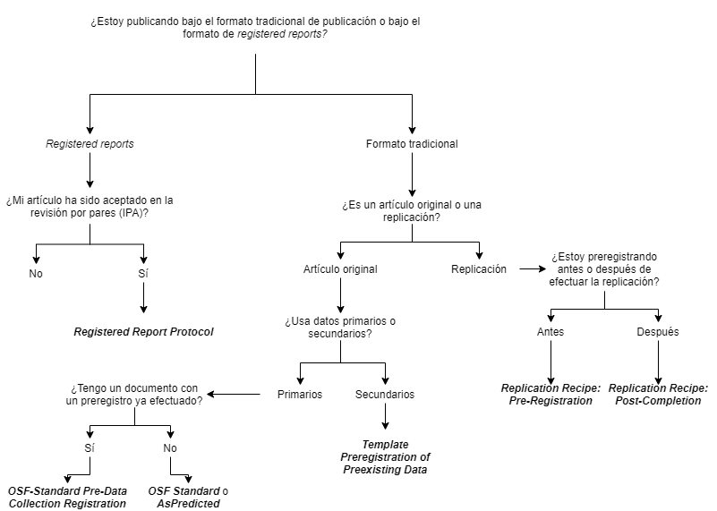